# dRelatório de Análise das Desigualdades Remuneratórias no Executivo Civil Federal

# 17 Interpretação dos resultados.

Os indicadores combinados (para 2025) permitem uma leitura mais rica da desigualdade remuneratória entre grupos ocupacionais do que o uso isolado do coeficiente de Gini. Em vez de captar apenas a concentração geral, a tabela separa três dimensões distintas: dispersão do núcleo da distribuição, distância entre base e topo extremo e heterogeneidade relativa entre segmentos.

### 17.0.1 O que revela o Gini

Os grupos com maior coeficiente de Gini são aqueles em que a remuneração está mais concentrada internamente. Isso indica maior desigualdade entre integrantes do mesmo agrupamento ocupacional. Em termos substantivos, tende a refletir as seguintes características:

- coexistência de cargos muito distintos no mesmo grupo;
- progressões remuneratórias assimétricas;
- presença simultânea de posições básicas e cargos de comando.

Já grupos com Gini menor tendem a apresentar carreiras mais lineares e tabeladas.

### 17.0.2 O que revela a razão P75/P25

A razão **P75/P25** mostra quantas vezes o rendimento do terceiro quartil supera o do primeiro quartil. Ela mede a desigualdade no “miolo” da distribuição, isto é, entre a base intermediária e o estrato superior típico, sem depender dos valores máximos. A interpretação é a de que

- Valores próximos de **1,3 a 1,6** sugerem compressão salarial.
- Valores acima de **2** indicam dispersão importante.
- Valores muito altos sugerem grupos internamente estratificados.

Se alguns grupos exibem Gini moderado, mas P75/P25 elevado, isso indica desigualdade disseminada entre muitos membros, não apenas concentrada em poucos casos extremos.

### 17.0.3 O que revela Máx/P25

Este talvez seja o indicador mais substantivamente poderoso da tabela. Ele mostra quantas vezes o maior rendimento do grupo supera o primeiro quartil. Quando o valor é muito alto há indicativo de há elite salarial interna muito destacada;

No setor público, isso frequentemente sinaliza estruturas hierárquicas fortes ou grupos que agregam posições muito heterogêneas.

### 17.0.4 Diferença entre Gap P75-P25 e Gap Máx-P25

### 17.0.5 Gap P75-P25

Mostra a desigualdade monetária entre quartis típicos. É a dispersão ordinária do grupo.

### 17.0.6 Gap Máx-P25

Mostra a distância entre o topo máximo e a base intermediária. Quando esse gap explode em relação ao gap interquartil, o grupo possui topo descolado.

Assim, se um grupo tem um gap P75-P25 moderado e um gap Máx-P25 altíssimo, então a maioria recebe valores relativamente próximos, mas existe uma pequena elite muito distante.

### 17.0.7 Tipologia substantiva dos grupos

A tabela normalmente permite identificar quatro tipos:

### 17.0.8 A. Carreiras homogêneas premium

- Gini baixo
- remuneração alta
- quartis próximos
- máximo não tão distante

### 17.0.9 Estruturas hierárquicas elitizadas

- Gini alto
- Máx/P25 muito alto
- grande Gap Máx-P25

Sugere comando concentrado no topo.

### 17.0.10 Grupos massivos e fragmentados

- Gini médio/alto
- P75/P25 alto
- topo não necessariamente extremo

Sugere heterogeneidade difusa.

### 17.0.11 Base administrativa comprimida

- baixos salários
- baixa dispersão
- pouca diferenciação interna

## 17.1 Implicação para o debate sobre desigualdade no setor público

Os resultados mostram que a desigualdade estatal não ocorre apenas entre carreiras (grupo de gestão/advogados públicos vs administrativos, por exemplo), mas também dentro de grupos ocupacionais agregados.

## 17.2 Principal conclusão provável

Se os grupos ordenados por **Máx/P25** diferem bastante dos ordenados por Gini, isso indica que existem dois fenômenos distintos:

1. desigualdade difusa entre muitos servidores;
2. concentração extrema no topo.

Essa distinção é crucial para políticas salariais.

## 17.3 9. Formulação para relatório

Os indicadores de 2025 sugerem que a desigualdade remuneratória no setor público federal assume formas distintas entre grupos ocupacionais. Em alguns segmentos, a dispersão salarial distribui-se ao longo de toda a estrutura interna; em outros, a principal característica é a existência de uma elite remuneratória muito distante do restante dos servidores. Isso indica que reformas voltadas à equidade devem distinguir desigualdade difusa de concentração no topo.

## 17.4 10. Próximo passo analítico recomendado

Cruzar esses indicadores com o tamanho dos grupos (`vinculos`) e com sua natureza ocupacional. Isso mostrará se a desigualdade está concentrada em grupos pequenos e estratégicos ou em segmentos massivos da burocracia.

# 18 12 C Analisando uma tabela completa com dados de remuneração, em vez de rendimento

Desigualdade da remuneração e peso dos grupos ocupacionais (2025)

| Grupo | Vínculos | P25 Remun. | P50 Remun. | P75 Remun. | Máximo | P75/P25 | Máx/P25 | Máx/P50 | Gap P75-P25 | Gap Máx-P25 |
| --- | --- | --- | --- | --- | --- | --- | --- | --- | --- | --- |
| Administrativos | 187.663 | 4.893 | 6.958 | 11.090 | 67.070 | 2.27 | 13.71 | 9.64 | 6.197 | 62.177 |
| Educação e Cultura | 161.183 | 10.482 | 14.468 | 19.880 | 40.554 | 1.90 | 3.87 | 2.80 | 9.398 | 30.072 |
| Saúde | 149.160 | 2.383 | 6.422 | 10.900 | 51.279 | 4.57 | 21.52 | 7.98 | 8.517 | 48.896 |
| Segurança Pública | 35.043 | 13.352 | 17.141 | 20.940 | 51.205 | 1.57 | 3.84 | 2.99 | 7.588 | 37.853 |
| Apoio e Manutênção Técnicos | 30.597 | 3.616 | 5.532 | 7.117 | 45.014 | 1.97 | 12.45 | 8.14 | 3.501 | 41.398 |
| Militares | 18.027 | 9.024 | 10.395 | 12.822 | 52.405 | 1.42 | 5.81 | 5.04 | 3.798 | 43.381 |
| Fiscalização e Contãole | 15.036 | 25.364 | 29.761 | 30.939 | 57.538 | 1.22 | 2.27 | 1.93 | 5.575 | 32.174 |
| Tecnologia da Informação | 11.274 | 5.282 | 8.933 | 11.624 | 49.343 | 2.20 | 9.34 | 5.52 | 6.342 | 44.061 |
| Carreiras Jurídicas | 8.900 | 29.761 | 29.761 | 29.761 | 61.458 | 1.00 | 2.07 | 2.07 | 0 | 31.697 |
| Regulação Econômica e Infraestrutura | 7.881 | 9.774 | 13.989 | 20.341 | 64.051 | 2.08 | 6.55 | 4.58 | 10.567 | 54.277 |
| Ciência e Tecnologia | 5.481 | 19.089 | 22.399 | 42.922 | 71.141 | 2.25 | 3.73 | 3.18 | 23.833 | 52.052 |
| Políticas de Trabalho, Previdência e Assistência Sociais | 4.689 | 12.350 | 13.901 | 14.207 | 25.270 | 1.15 | 2.05 | 1.82 | 1.857 | 12.920 |
| Obsoletos | 4.144 | 3.404 | 5.614 | 6.106 | 28.123 | 1.79 | 8.26 | 5.01 | 2.702 | 24.719 |
| Agricultura, Agropecuária e Meio Ambiênte | 3.684 | 5.098 | 6.635 | 12.139 | 33.624 | 2.38 | 6.60 | 5.07 | 7.041 | 28.526 |
| Agêntes Políticos | 1.770 | 9.074 | 10.224 | 11.610 | 46.366 | 1.28 | 5.11 | 4.54 | 2.536 | 37.292 |
| Diplomacia | 1.756 | 0 | 0 | 12.618 | 45.624 | Inf | Inf | Inf | 12.618 | 45.624 |
| Gestão e Políticas Públicas | 1.685 | 29.833 | 29.833 | 29.833 | 43.483 | 1.00 | 1.46 | 1.46 | 0 | 13.650 |
| Carreiras de Inteligência | 966 | 18.520 | 21.448 | 25.719 | 38.362 | 1.39 | 2.07 | 1.79 | 7.199 | 19.842 |
| Economia e Finanças | 535 | 26.902 | 29.833 | 33.583 | 40.915 | 1.25 | 1.52 | 1.37 | 6.681 | 14.013 |
| Serviços Auxiliares e Serviçagem | 291 | 4.189 | 4.619 | 5.080 | 7.453 | 1.21 | 1.78 | 1.61 | 891 | 3.264 |
| Altos Dirigêntes | 1 | 18.136 | 18.136 | 18.136 | 18.136 | 1.00 | 1.00 | 1.00 | 0 | 0 |

# 19 13. Rendimento médio e desigualdade

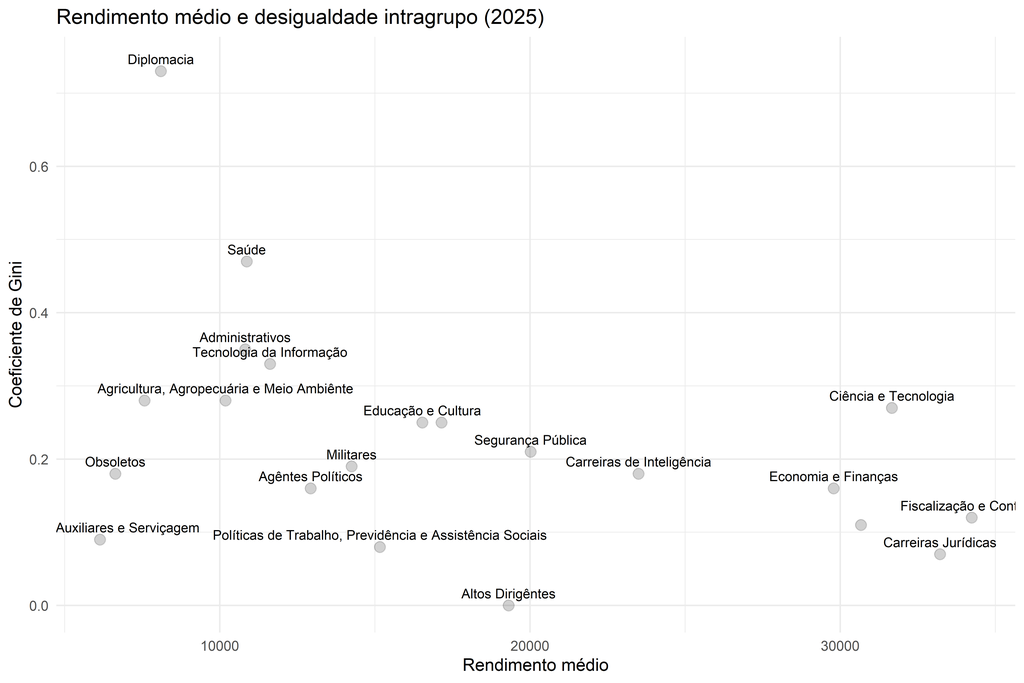

# 20 14. Modelo estatístico exploratório

| term | estimate | std.error | statistic | p.value |
| --- | --- | --- | --- | --- |
| (Intercept) | 0.3201002 | 0.0447820 | 7.1479629 | 0.0000000 |
| media_vr_rendim | -0.0000073 | 0.0000019 | -3.8656250 | 0.0002298 |
| servidores | 0.0000007 | 0.0000004 | 1.7783840 | 0.0792882 |
| qtde_cargos | -0.0000138 | 0.0000574 | -0.2398823 | 0.8110589 |
| factor(ano)2023 | -0.0032536 | 0.0439844 | -0.0739707 | 0.9412255 |
| factor(ano)2024 | 0.0133060 | 0.0441283 | 0.3015310 | 0.7638225 |
| factor(ano)2025 | 0.0162619 | 0.0442440 | 0.3675493 | 0.7142176 |

# 21 15. Principais achados

```
## Entre 2022 e 2025, o coeficiente médio de Gini variou de 0,229 para 0,227.
```

Os resultados sugerem heterogeneidade relevante entre grupos ocupacionais. Alguns segmentos concentram rendimentos em grau superior aos demais, e a desigualdade interna não coincide necessariamente com maiores médias salariais. Em conjunto, os dados sugerem que a estrutura remuneratória estatal combina regras padronizadas com bolsões de forte dispersão interna.

# 22 16. Conclusão

A desigualdade no setor público federal não ocorre apenas entre carreiras, mas também dentro delas. O monitoramento sistemático do coeficiente de Gini por grupos ocupacionais permite identificar distorções distributivas, mudanças institucionais e trajetórias diferenciadas entre segmentos da burocracia estatal.

Esse tipo de evidência pode subsidiar debates sobre desenho de carreiras, política remuneratória, incentivos e racionalização administrativa.

# 23 17. Exportação opcional